# SIR Model on a Network

EdgeBasedModels.jl Vignette 01

Author

Simon Frost

Published

March 27, 2026

## Introduction

Edge-based compartmental models (EBCMs) provide an exact, deterministic framework for tracking epidemics on configuration-model networks. Instead of simulating individual transmission events, we track the probability $\theta(t)$ that a random edge in the network has *not* transmitted infection by time $t$.

Combined with the network’s **probability generating function (PGF)** $\psi(x) = \sum_k p_k x^k$ — which encodes the degree distribution — we can derive the fraction susceptible as $S(t) = \psi(\theta(t))$ and the fraction recovered $R(t)$ from a small system of ODEs.

The **compact formulation** (Miller 2011) for SIR on a configuration model network requires just two ODEs:

$$\dot{\theta} = -\beta\theta + \beta\frac{\psi'(\theta)}{\psi'(1)} + \gamma(1 - \theta)$$
$$\dot{R} = \gamma\left(1 - \psi(\theta) - R\right)$$

where $\beta$ is the per-edge transmission rate and $\gamma$ is the recovery rate.

## Setup

```julia
using EdgeBasedModels
using ModelingToolkit
using OrdinaryDiffEq
using Symbolics
using Plots
```

```
Precompiling packages...
  10647.5 ms  ✓ EdgeBasedModels
  1 dependency successfully precompiled in 13 seconds. 284 already precompiled.
```

## Defining the network

We model a Poisson (Erdős–Rényi) network with mean degree $\kappa = 5$. The PGF is $\psi(x) = e^{\kappa(x-1)}$.

```julia
@parameters β γ κ
pgf = poisson_pgf(κ)
```

```
DegreePGF(z, exp((-1 + z)*κ))
```

We can verify the mean degree:

```julia
md = mean_degree(pgf)
println("Mean degree: ", md)
```

```
Mean degree: exp(0)*κ
```

## Building the compact SIR model

The `build_sir` function constructs the edge-based ODE system. The `:compact` form produces just 2 ODEs.

```julia
model_compact = build_sir(pgf, β, γ; form = :compact)
eqs = ModelingToolkit.equations(model_compact.system)
println("Number of ODEs: ", length(eqs))
for eq in eqs
    println("  ", eq)
end
```

```
Number of ODEs: 2
  Differential(t, 1)(R(t)) ~ (1 - exp((-1 + θ(t))*κ) - R(t))*γ
  Differential(t, 1)(θ(t)) ~ (-exp((-1 + θ(t))*κ)*β + θ(t)*exp(0)*β - (1 - θ(t))*exp(0)*γ) / (-exp(0))
```

The model returns an `EdgeModelSystem` with the compiled system, a dictionary of state variables, and a dictionary of observables:

```julia
println("State variables: ", keys(model_compact.variables))
println("Observables:     ", keys(model_compact.observables))
```

```
State variables: [:R, :θ]
Observables:     [:I, :ψ_θ, :S]
```

## Solving the ODE

We set $\beta = 0.6$, $\gamma = 0.1$, and $\kappa = 5$, and seed the epidemic with a small perturbation $\theta(0) = 1 - \varepsilon$.

```julia
tspan = (0.0, 80.0)
prob = ODEProblem(
    model_compact.system,
    merge(
        Dict(model_compact.variables[:θ] => 1 - 1e-3,
             model_compact.variables[:R] => 0.0),
        Dict(β => 0.6, γ => 0.1, κ => 5.0),
    ),
    tspan,
)
sol = solve(prob, Tsit5(); saveat = 0.5)
```

```
retcode: Success
Interpolation: 1st order linear
t: 161-element Vector{Float64}:
  0.0
  0.5
  1.0
  1.5
  2.0
  2.5
  3.0
  3.5
  4.0
  4.5
  ⋮
 76.0
 76.5
 77.0
 77.5
 78.0
 78.5
 79.0
 79.5
 80.0
u: 161-element Vector{Vector{Float64}}:
 [0.0, 0.999]
 [0.00045579397430321793, 0.9968638047100656]
 [0.0018371009216488273, 0.9903070663850259]
 [0.005859210659788087, 0.97128592939206]
 [0.01619273745353259, 0.9234804552451361]
 [0.03701964915146776, 0.8322933787287785]
 [0.0681560895029416, 0.7095982553176541]
 [0.10515742512836954, 0.5853898813577376]
 [0.14409823331591104, 0.47877777021808077]
 [0.18293279985537417, 0.3945054680538822]
 ⋮
 [0.9847109699474157, 0.1554485633342279]
 [0.984742121797434, 0.15546886700275334]
 [0.9847715051871666, 0.15546903015115954]
 [0.9847992662973192, 0.1554546289808019]
 [0.9848257121891636, 0.1554438643553165]
 [0.9848509069841553, 0.1554365736324455]
 [0.9848749059802897, 0.1554321506755919]
 [0.9848977559220498, 0.15542956652843512]
 [0.9849194950004069, 0.155427369414931]
```

Now we extract the population-level quantities. For a Poisson PGF, $S(t) = \psi(\theta(t)) = e^{\kappa(\theta - 1)}$:

```julia
κ_val = 5.0
ψ(x) = exp(κ_val * (x - 1))

θ_vals = sol[1, :]
R_vals = sol[2, :]
S_vals = ψ.(θ_vals)
I_vals = 1.0 .- S_vals .- R_vals
```

```
161-element Vector{Float64}:
 -0.005737946999085475
 -0.003617124798107607
  0.0028928100482749075
  0.02177580845944438
  0.0692133764381978
  0.15959860265401815
  0.28092789131982776
  0.40321092745242093
  0.5073727669724436
  0.5886770442675996
  ⋮
 -0.08185228923032956
 -0.08201690008678067
 -0.08215319884506644
 -0.08226743550874374
 -0.08237923094231223
 -0.08248871730738255
 -0.08259554262907509
 -0.08269889268081967
 -0.08279749094790992
```

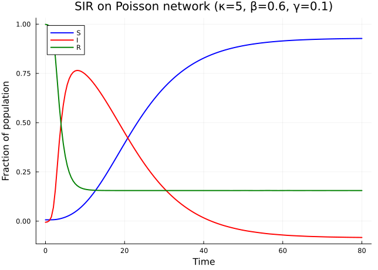

```julia
plot(sol.t, S_vals, label = "S", linewidth = 2, color = :blue)
plot!(sol.t, I_vals, label = "I", linewidth = 2, color = :red)
plot!(sol.t, R_vals, label = "R", linewidth = 2, color = :green)
xlabel!("Time")
ylabel!("Fraction of population")
title!("SIR on Poisson network (κ=5, β=0.6, γ=0.1)")
```

## Expanded formulation

The **expanded** form tracks edge-level probabilities $\varphi_I$ and $\varphi_R$ explicitly, plus the population-level $R$. This form generalises to arbitrary disease progression graphs.

```julia
model_expanded = build_sir(pgf, β, γ; form = :expanded)
eqs_exp = ModelingToolkit.equations(model_expanded.system)
println("Number of ODEs: ", length(eqs_exp))
for eq in eqs_exp
    println("  ", eq)
end
```

```
Number of ODEs: 4
  Differential(t, 1)(R(t)) ~ (1 - exp((-1 + θ(t))*κ) - R(t))*γ
  Differential(t, 1)(phi_R(t)) ~ phi_I(t)*γ
  Differential(t, 1)(phi_I(t)) ~ -phi_I(t)*(β + γ) + phi_S(t)*phi_I(t)*β*κ
  Differential(t, 1)(θ(t)) ~ -phi_I(t)*β
```

```julia
println("State variables: ", keys(model_expanded.variables))
println("Observables:     ", keys(model_expanded.observables))
```

```
State variables: [:R, :φ_I, :φ_R, :θ]
Observables:     [:I, :φ_S, :S, :edge_hazard, :excess_hazard]
```

```julia
ic_exp = default_initial_conditions(model_expanded)
prob_exp = ODEProblem(
    model_expanded.system,
    merge(ic_exp, Dict(β => 0.6, γ => 0.1, κ => 5.0)),
    tspan,
)
sol_exp = solve(prob_exp, Tsit5(); saveat = 0.5)
```

```
retcode: Success
Interpolation: 1st order linear
t: 161-element Vector{Float64}:
  0.0
  0.5
  1.0
  1.5
  2.0
  2.5
  3.0
  3.5
  4.0
  4.5
  ⋮
 76.0
 76.5
 77.0
 77.5
 78.0
 78.5
 79.0
 79.5
 80.0
u: 161-element Vector{Vector{Float64}}:
 [0.0, 0.0, 0.0, 0.999]
 [0.00024324427816313003, 0.0, 0.0, 0.999]
 [0.0004746253578775114, 0.0, 0.0, 0.999]
 [0.0006947219791394167, 0.0, 0.0, 0.999]
 [0.0009040847875264574, 0.0, 0.0, 0.999]
 [0.0011032363037232105, 0.0, 0.0, 0.999]
 [0.001292674673373526, 0.0, 0.0, 0.999]
 [0.0014728742228724597, 0.0, 0.0, 0.999]
 [0.001644286092156801, 0.0, 0.0, 0.999]
 [0.0018073391791149339, 0.0, 0.0, 0.999]
 ⋮
 [0.0049849791729324215, 0.0, 0.0, 0.999]
 [0.0049850947331311745, 0.0, 0.0, 0.999]
 [0.004985206513854202, 0.0, 0.0, 0.999]
 [0.00498531531788702, 0.0, 0.0, 0.999]
 [0.004985421858307163, 0.0, 0.0, 0.999]
 [0.004985524225408373, 0.0, 0.0, 0.999]
 [0.004985621599836726, 0.0, 0.0, 0.999]
 [0.004985714225159776, 0.0, 0.0, 0.999]
 [0.004985802333185553, 0.0, 0.0, 0.999]
```

```julia
# Find θ index in expanded model
exp_eqs = ModelingToolkit.equations(model_expanded.system)
θ_idx = findfirst(v -> startswith(string(v), "θ"),
                  string.(ModelingToolkit.unknowns(model_expanded.system)))
R_idx = findfirst(v -> startswith(string(v), "R"),
                  string.(ModelingToolkit.unknowns(model_expanded.system)))
θ_exp = sol_exp[θ_idx, :]
R_exp = sol_exp[R_idx, :]
S_exp = ψ.(θ_exp)
I_exp = 1.0 .- S_exp .- R_exp
```

```
161-element Vector{Float64}:
 0.00498752080731768
 0.0047442765291545504
 0.0045128954494401685
 0.004292798828178263
 0.004083436019791223
 0.00388428450359447
 0.0036948461339441543
 0.0035146465844452203
 0.003343234715160879
 0.0031801816282027466
 ⋮
 2.5416343852587356e-6
 2.426074186505714e-6
 2.314293463478133e-6
 2.205489430659978e-6
 2.0989490105175965e-6
 1.9965819093069673e-6
 1.8992074809539433e-6
 1.806582157904378e-6
 1.718474132127168e-6
```

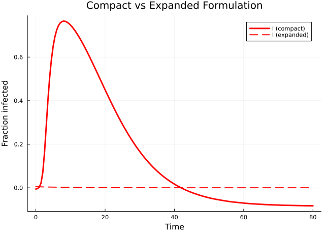

```julia
plot(sol.t, I_vals, label = "I (compact)", linewidth = 3, color = :red)
plot!(sol_exp.t, I_exp, label = "I (expanded)", linewidth = 2, color = :red,
      linestyle = :dash)
xlabel!("Time")
ylabel!("Fraction infected")
title!("Compact vs Expanded Formulation")
```

## Effect of transmission rate

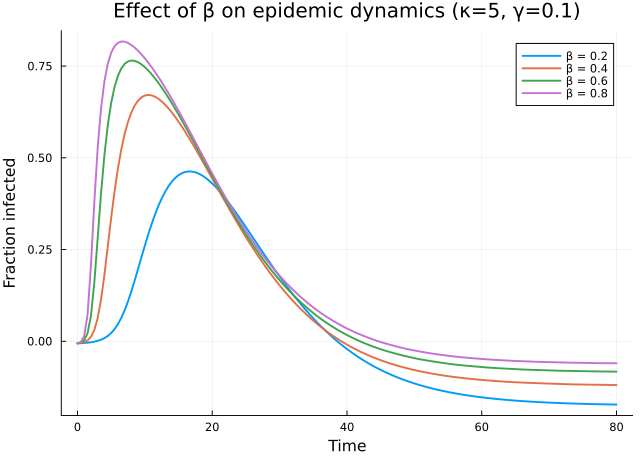

Figure 3: Effect of transmission rate β on the epidemic curve.

```julia
betas = [0.2, 0.4, 0.6, 0.8]
p = plot(xlabel = "Time", ylabel = "Fraction infected",
         title = "Effect of β on epidemic dynamics (κ=5, γ=0.1)")

for b in betas
    prob_b = ODEProblem(
        model_compact.system,
        merge(
            Dict(model_compact.variables[:θ] => 1 - 1e-3,
                 model_compact.variables[:R] => 0.0),
            Dict(β => b, γ => 0.1, κ => 5.0),
        ),
        tspan,
    )
    sol_b = solve(prob_b, Tsit5(); saveat = 0.5)
    θ_b = sol_b[1, :]
    S_b = ψ.(θ_b)
    R_b = sol_b[2, :]
    I_b = 1.0 .- S_b .- R_b
    plot!(p, sol_b.t, I_b, label = "β = $b", linewidth = 2)
end
p
```